# Part 2

# "De-fault Words" in Our Stars:

## Theme Extraction through Clustering of n-starred Amazon.com product reviews

## I. Executive Summary

Amazon.com is a technology company that has revolutionized commercial trade through its e-commerce platform. It has consistently been at the forefront of innovation through its disruption of well-established industries. Amazon’s key differentiator is its company wide attention to Customer Service. Part of this approach is ensuring that complete and reliable product information is readily available to its customers through customer reviews. These reviews guide shoppers in their purchase decisions as they learn from fellow customers. **To reduce time going through reviews, could customer reviews be filtered further according to common themes per n-star rating?** This project aims to determine themes from customer reviews corresponding to its star rating as seen in the amazon.com product review section.

```python
import pandas as pd
import numpy as np
import matplotlib.pyplot as plt
import seaborn as sns
```

## II. Methodology

Analysis and Clustering of the titles will be done in the manner outlined below:

- **Data collection through web scraping using BeautifulSoup and mining the McAuley's Amazon Dataset**
  - Identification of relevant statistics
  - Pre - processing
- **Exploratory Data Analysis**
- **Vector Space Representation using TFIDF**
- **Determination of Optimal Number of NMF Components and Clusters (k)**
  - Dimensionality Reduction using NMF with number of components as number of clusters
  - Hard clustering using the highest NMF component probability of an observation
  - Evaluation of Internal Validation Criteria
- **Dimensionality Reduction using Optimal k Principal Components**
- **Cluster Analysis: Hard Clustering into k Clusters**
  - Visualization of Clusters
- **Conclusion**
  - Results
  - Insights
  - Recommendations

## III. Data

Refer to Part 1 for Data Collection

### A. Data Description

Data collected regarding product reviews are represented in a DataFrame with 12,105 rows and 3 columns corresponding to the product id, its star rating and the product review. In order to augment the data collected from direct scraping, the authors utlized the the amazon product databse stored made available via the Asian Institute of Management (AIM) ACCeSs Lab. To provide statistical context, mean, median, maximum, and minimum amounts of words per review is presented below.

The distribution of customer review star ratings in the dataset are as follows:

```python
raw = pd.read_csv("amazon_reviews.csv")
raw = raw.drop_duplicates()
```

```python
print("Data dimensions: {}".format(raw.shape))
print("Missing values: {}".format(raw.isnull().sum().sum()))
raw.head()
```

```
Data dimensions: (12105, 3)
Missing values: 0
```

|  | product_id | star_rating | reviews |
| --- | --- | --- | --- |
| 0 | B00OYRW4UE | 5 | Exactly as described. Good quality. Shipped fast |
| 1 | B0000537JQ | 5 | It is great |
| 2 | B00HXXO332 | 5 | It's really nice it works great. You have the ... |
| 3 | B00EOB0JA2 | 2 | The kit works fine... simple cheap plastic tho |
| 4 | B00OC2O1UC | 4 | It works better than anything else ive tried |

```
Mean Words per Review: 46
Median Words per Review: 17
Min Words per Review: 1
Max Words per Review: 2382
```

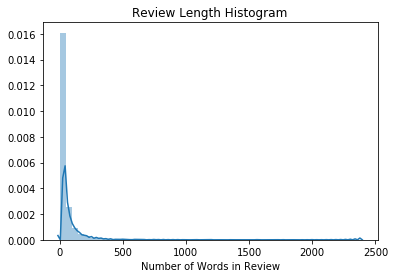

```python
review_lengths = [len(review.split()) for review in raw.reviews]
print("Mean Words per Review: {:0.0f}".format(np.mean(review_lengths)))
print("Median Words per Review: {:0.0f}".format(np.median(review_lengths)))
print("Min Words per Review: {:d}".format(min(review_lengths)))
print("Max Words per Review: {:d}".format(max(review_lengths)))

sns.distplot(review_lengths)
plt.title("Review Length Histogram")
plt.xlabel("Number of Words in Review");
```

```python
print("Portion of high-rated reivews: {:0.1f}%".format(
    sum(raw.star_rating > 3)/raw.shape[0]*100))
print("Portion of neutral reivews: {:0.1f}%".format(
    sum(raw.star_rating == 3)/raw.shape[0]*100))
print("Portion of low-rated reivews: {:0.1f}%".format(
    sum(raw.star_rating < 3)/raw.shape[0]*100))
```

```
Portion of high-rated reivews: 79.4%
Portion of neutral reivews: 7.4%
Portion of low-rated reivews: 13.3%
```

### B. Data Pre-processing

An initial wordcloud is generated to visualize the raw data. Stopwords are removed to allow for more efficient use of the data by filtering out words with the least contextual significance. Special characters, non- informative tags, alphanumeric, and other unnecessary characters are removed from the data through regular expression (regex) search patterns. Customer reviews in the amazon.com platform employ the 5 star rating concept where products with low customer satsifaction rating are given 1 star, and products with high satisfaction rating are given 5. In this section, reviews are segmented according to the review ratings: High = 4 or 5 star reviews, Neutral = 3 star reviews, Low = 1 or 2 star reviews.

The processed output would be a used for subsequent EDA and vectorization that ensures compact, separated, balanced, and parsimonious clusters with more insightful results.

```python
from collections import Counter
from wordcloud import STOPWORDS, WordCloud
import re
```

```python
raw = pd.read_csv("amazon_reviews.csv")
df = raw.copy()

ratings = []
for star in df.star_rating:
    if star < 3:
        rating = 'low'
    if star == 3:
        rating = 'neutral'
    if star > 3:
        rating = 'high'
    ratings.append(rating)
df['ratings'] = ratings
```

```python
stopwords = set(
    ['br', 'the', 'i', 'me', 'my', 'myself', 'we', 'our', 'ours', 'ourselves',
     'you', "you're", "you've", "you'll", "you'd", 'your', 'yours',
     'yourself', 'yourselves', 'he', 'him', 'his', 'himself', 'she', "she's",
     'her', 'hers', 'herself', 'it', "it's", 'its', 'itself', 'they', 'them',
     'their', 'theirs', 'themselves', 'what', 'which', 'who', 'whom', 'this',
     'that', "that'll", 'these', 'those', 'am', 'is', 'are', 'was', 'were',
     'be', 'been', 'being', 'have', 'has', 'had', 'having', 'do', 'does',
     'did', 'doing', 'a', 'an', 'the', 'and', 'but', 'if', 'or', 'because',
     'as', 'until', 'while', 'of', 'at', 'by', 'for', 'with', 'about',
     'against', 'between', 'into', 'through', 'during', 'before', 'after',
     'above', 'below', 'to', 'from', 'up', 'down', 'in', 'out', 'on', 'off',
     'over', 'under', 'again', 'further', 'then', 'once', 'here', 'there',
     'when', 'where', 'why', 'how', 'all', 'any', 'both', 'each', 'few',
     'more', 'most', 'other', 'some', 'such', 'only', 'own', 'same', 'so',
     'than', 'too', 'very', 's', 't', 'can', 'will', 'just', 'don', "don't",
     'should', "should've", 'now', 'd', 'll', 'm', 'o', 're', 've', 'y',
     'ain', 'aren', "aren't", 'couldn', "couldn't", 'didn', "didn't", 'doesn',
     "doesn't", 'hadn', "hadn't", 'hasn', "hasn't", 'haven', "haven't", 'isn',
     "isn't", 'ma', 'mightn', "mightn't", 'mustn', "mustn't", 'needn',
     "needn't", 'shan', "shan't", 'shouldn', "shouldn't", 'wasn', "wasn't",
     "weren", "weren't", 'won', "won't", 'wouldn', "wouldn't", "book", "product",
     "one"])

stopwords = stopwords.union(set(STOPWORDS))
```

```python
def decontracted(phrase):
    # specific
    phrase = re.sub(r"won't", "will not", phrase)
    phrase = re.sub(r"can\'t", "can not", phrase)

    # general
    phrase = re.sub(r"n\'t", " not", phrase)
    phrase = re.sub(r"\'re", " are", phrase)
    phrase = re.sub(r"\'s", " is", phrase)
    phrase = re.sub(r"\'d", " would", phrase)
    phrase = re.sub(r"\'ll", " will", phrase)
    phrase = re.sub(r"\'t", " not", phrase)
    phrase = re.sub(r"\'ve", " have", phrase)
    phrase = re.sub(r"\'m", " am", phrase)
    return phrase
```

```python
from tqdm import tqdm
preprocessed_reviews = []
# tqdm is for printing the status bar
for review in tqdm(df['reviews'].values):
    review = re.sub(r"&amp", '', review)
    review = re.sub(r"http\S+", "", review) # Removing http tags
    review = decontracted(review) # removing based on above functions
    review = re.sub("\S*\d\S*", " ", review).strip() # Removing alphanumeric
    review = re.sub('[^A-Za-z]+', ' ', review) # removing special characters
    review = ' '.join(e.lower() for e in review.split() if e.lower() not in stopwords)
#     review = get_lemmatized(review)
    preprocessed_reviews.append(review.strip())
df['reviews'] = preprocessed_reviews
```

```python
ratings = []
for star in df.star_rating:
    if star < 3:
        rating = 'Low'
    if star == 3:
        rating = 'Neutral'
    if star > 3:
        rating = 'High'
    ratings.append(rating)
df['ratings'] = ratings
```

## III. Exploratory Data Analysis

Data for each of the ratings were subjected to EDA to identify inherent patterns, if any. Most common phrases and words per rating are shown below.

```python
def ngrams(review_list, n=1, top_n=10):
    """Determine the contiguous sequence of n words in a text.

    Determine n-gram strings per paragraph of the text and use them as
    keys with their counts as values. Sort the pairs first by frequency
    then alphabetically.

    Parameter
    ----------
    n : int
        Number of continuous words in a sequence.

    Returns
    -------
    ngrams_counts : dict
        Contains key-value pairs with n-grams as keys and their
        frequencies as values.
    """
    temp = []
    for review in review_list:
        words = review.split()
        if len(words) < n:
            continue
        start = 0
        end = n
        while end <= len(words):
            temp.append(' '.join(words[start:end]))
            start += 1
            end += 1
    temp = sorted(Counter(temp).items(),
                  key=lambda x: (-x[1], x[0]))
    ngrams_counts = dict(temp[:top_n])
    return ngrams_counts
```

```python
# Segment data into groups via their rating
ratings = ['Low', 'Neutral', 'High']
groups = {i:df.groupby('ratings').get_group(i) for i in ratings}
```

#### Common Bigrams and Words

Individual Words identified for all three rating types do not seem to provide context with respect to its rating.

The histogram of Bigrams on the other hand, provides more context relative to both low and high rated reviews. This provides a visual representation of the processed data.

Bigrams of Neutral ratings present phrases seemingly related to products or services such as "batman beyond", presenting that Neutral reviews may contain product details more than customer sentiments as seen in the Low and High rated reviews.

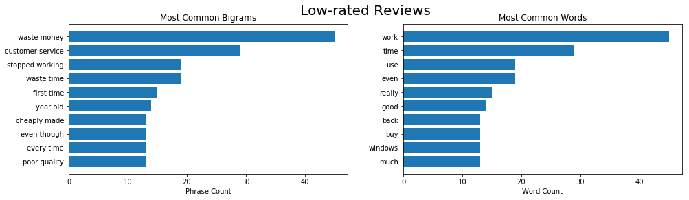

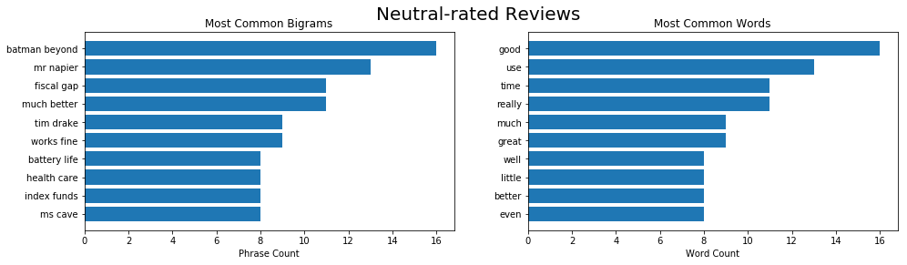

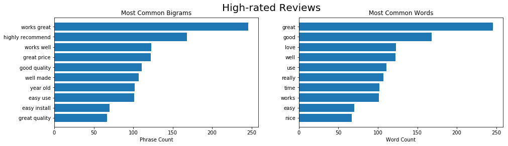

```python
# Most Common Bigrams and Words
for group in groups:

    fig, (ax1, ax2) = plt.subplots(1, 2, figsize=(16, 4))
    fig.suptitle("{}-rated Reviews".format(group), fontsize=20)

    word_2 = ngrams(list(groups[group].reviews), 2, 10)
    ax1.barh(list(word_2.keys())[::-1], list(word_2.values())[::-1])
    ax1.set_xlabel("Phrase Count")
    ax1.set_title("Most Common Bigrams".format(group))

    word_3 = ngrams(list(groups[group].reviews), 1, 10)
    ax2.barh(list(word_3.keys())[::-1], list(word_2.values())[::-1])
    ax2.set_xlabel("Word Count")
    ax2.set_title("Most Common Words".format(group))
```

#### Bigrams Low and High rated reviews show customer present phrases related to the quality and perceived satisfaction derived from the product.

## IV. Vectorization

```python
from sklearn.feature_extraction.text import TfidfVectorizer
from sklearn.decomposition import NMF
from scipy.spatial.distance import cosine, euclidean
from sklearn.metrics import calinski_harabaz_score, silhouette_score
```

### 1. Vector Space Representation

- **TF-IDF:**

Term frequency-inverse document frequency is often used in information retrieval and text mining for converting text to a vector. It is considered as a marked improvement overt the traditional Bag of Words representation as it incorporates weights as a statistical measure used to evaluate the importance of a word in a document corpus. While the Tf increases as the frequency of words in the corpus increases, the IDF offsets this by giving more preference to the less frequent words.

- **Tf-idf Implementation:**

Resulting Bigrams from the previous section are converted into the the Tf-idf vector, where word counts, inverse document frequency values are computed as well as Tf-idf scores.

```python
tfidf_models = {i : TfidfVectorizer(token_pattern=r'[a-z-]+',
                                   stop_words='english',
                                   ngram_range=(2,2),
                                   min_df=2) for i in ratings}
bow = dict()
reviews = dict()
for i in ratings:
    bow_ = tfidf_models[i].fit_transform(list(groups[i].reviews))
    nonzeros = bow_.sum(axis=1).nonzero()[0]
    bow_ = bow_[nonzeros]
    bow[i] = bow_
    reviews[i] = groups[i].iloc[nonzeros,:].reviews
```

### 2. Determination of Optimal Number of NMF Components and Clusters (k)

- **NMF**

  NMF stands for non-negative matrix factorization, a technique used for obtaining low rank representation of matrices with zero or positive elements. NMF is specially useful for Topic Modeling and especially useful for clustering of text data where in it is helpful in finding meaningful patterns between words. Hence NMF has a distinctive edge over the traditional clustering methods such as Kmeans and Agglomerative Clustering.

  Given a data matrix A of m rows and n columns with each and every element $a_{ij} ≥ 0$, NMF outputs matrices W and H of size m rows and k columns, and k rows and n columns, respectively, such that $A≈WH,$ and every element of matrices W and H is either zero or positive. The quantity k is set by the user and is required to be equal or less than the smallest of m and n. The matrix W is generally called the dictionary or basis matrix, and H is known as expansion or coefficient matrix.

  The matrices W and H are minimized by calculating the Frobenius norm : $$ ||A-WH||^2$$

  Although NMF has already had many success stories in clustering, one challenge in the widespread use of NMF as a clustering method lie in its correctness. While dimension reduction and clustering are closely related, they have different goals and different cost functions to optimize. The goal of NMF is to approximate the original data points in a latent subspace, while the goal of clustering is to partition the data points into several clusters so that the intra-cluster distance is small and the inter-cluster distance is as large as possible. In order to use NMF as a clustering method in the right circumstances, we need to know first when the latent subspace corresponds well to the actual cluster structures. Another issue of using NMF as a clustering method is its time and space complexity, the Frobenius equation above suggests that finding the cost function is an np-hard problem and hence computationally expensive.
- **Choice of Parameter for K**

The choice of the hyper-parameter K remains the single most important criteria for clustering. We have used a variety of internal - criterias for this purpose:

1. **Calinski-Harabasz Index:**

   The Calinski-Harabasz index (𝐶𝐻) evaluates the cluster validity based on the average between- and withincluster sum of squares. It measures separation based on the maximum distance between cluster centers, and measures compactness based on the sum of distances between objects and their cluster center. $$s(K) = \frac{B(K)/(K-1)}{W(K)/(n-K)}$$

   where $B(K)$ is the between group dispersion matrix and $W(K)$is the within-cluster dispersion matrix defined by:

   $$B(K) = \sum_{k=1}^K n_k \lvert\lvert \bar x_k - \bar x \rvert\rvert_2^2,$$ $$W(K) = \sum_{k=1}^K \sum_{x \in C_k} \lvert\lvert x - \bar x_k \rvert\rvert_2^2,$$

   with $n$ be the number of points in our data, $C_k$ be the set of points in cluster $k$, $\bar x_k$ be the center of cluster $k$, $\bar x$ be the center of all points, $n_k$ be the number of points in cluster $k$ and $n$ be the number of points. The higher the value of this measure, the more defined the clusters are.
1. **Silhouette Coefficient:**

   Let $Davg^{in}_i$ be the average distance of $x_i$ to data points within the cluster of $x_i$, and $Dmin^{out}_i$ be the smallest average distance to points other than its own cluster. The silhouette coefficient $S_i$ for the $i$th data point specific to the ith object, is as follows: $$ S_i = \frac{Dmin^{out}_i − Davg^{in}_i}{\max\{{Dmin^{out}_i}, Davg^{in}_i\}} $$ The overall silhouette coefficient is the average of $S_i$. Its value is in the the range (−1,1). Large positive values indicate highly separated clustering, and negative values are indicative of some level of “mixing” of data points from different clusters. This is because $Dmin^{out}_i$ will be less than $Davg^{in}_i$ only in cases where data point $x_i$ is closer to at least one other cluster than its own cluster. One advantage of this coefficient is that the absolute values provide a good intuitive feel of the quality of the clustering.
1. **Intra-Inter cluster Distance ratio:**

   We sample $r$ pairs of data points from the underlying data. We then take the ratio of the average distance of pairs $P$ that belong to the same cluster, and the average distance of pairs $Q$ that belong to different clusters: $$ Intra/Inter = \frac{\sum_{(x_i, x_j) \in P)} Dist(x_i, x_j)/\left|P\right|}{\sum_{(x_i, x_j) \in Q)} Dist(x_i, x_j)/\left|Q\right|}. $$ Small values of this measure indicate better clustering behavior.

```python
def intra_to_inter(X, y, dist, r):
    """Compute intracluster to intercluster distance ratio

    Parameters
    ----------
    X : array
        Design matrix with each row corresponding to a point
    y : array
        Class label of each point
    dist : callable
        Distance between two points. It should accept two arrays, each
        corresponding to the coordinates of each point
    r : integer
        Number of pairs to sample

    Returns
    -------
    ratio : float
        Intracluster to intercluster distance ratio
    """
    dist_P = []; dist_Q = []
    np.random.seed(2020)
    for i, j in np.random.randint(low=0, high=len(y), size=[r,2]):
        if i == j:
            continue
        elif y[i] == y[j]:
            dist_P.append(dist(X[i], X[j]))
        else:
            dist_Q.append(dist(X[i], X[j]))
    ratio = np.nan if len(dist_P)==0 else np.mean(dist_P)/np.mean(dist_Q)
    return ratio
```

```python
def k_test(rating, tfidf_matrix, k_max, k_spec):
    """Plot internal validation results at differet k number of clusters.

    Parameters
    ----------
    rating: str
        Amazon star ratings, {'Low', 'Neutral', 'High'}
    tfidf_matrix : csr_matrix
        Tf-idf-weighted document-term sparse matrix
    linkage matrix : np.array
        Condensed linkage distance matrix
    k_max : integer
        Maximum number of clusters to consider
    k_spec : integer
        Number of clusters to select

    Returns
    -------
    matplotlib.pylot.figure
        Internal Validation Plots of the Calinski-Harabasz Index,
        Intracluster to Intercluster Distance Ratio, and
        Silhouette Coefficient
    """
    chs, iidrs, scs = ([], [], [])
    ks = range(2,k_max+1)
    for k in ks:
        nmf = NMF(n_components=k, solver="mu", random_state=1208)
        nmf_transform = nmf.fit_transform(tfidf_matrix)
        pred = nmf_transform.argmax(axis=1)
        chs.append(calinski_harabaz_score(tfidf_matrix.todense(), pred))
        iidrs.append(intra_to_inter(tfidf_matrix.todense(), pred, cosine, 200))
        scs.append(silhouette_score(tfidf_matrix, pred))

    fig, (ax0, ax1, ax2) = plt.subplots(1, 3, figsize=(15, 5))
    ax0.plot(ks, chs, 'o-')
    ax0.set_ylabel('Calinski-Harabasz Index');
    ax0.set_xlabel('Number of Clusters')
    ax1.plot(ks, iidrs, 'o-')
    ax1.set_ylabel('Intra to Intercluster Distance Ratio')
    ax1.set_xlabel('Number of Clusters')
    ax2.plot(ks, scs, 'o-')
    ax2.set_ylabel('Silhouette Coefficient')
    ax2.set_xlabel('Number of Clusters')
    ax0.grid(True); ax1.grid(True); ax2.grid(True); plt.close()
    ax0.set_xlabel('Number of Clusters')
    fig.suptitle("{}-rated Reviews".format(rating), x=0, y=.95,
                 horizontalalignment='left', verticalalignment='top',
                 fontsize = 24)
    fig.tight_layout(rect=[0, 0, 1, 0.9])
    return fig
```

```python
def k_test(rating, tfidf_matrix, k_max, k_spec):
    """Plot internal validation results at differet k number of clusters.

    Parameters
    ----------
    rating: str
        Amazon star ratings, {'Low', 'Neutral', 'High'}
    tfidf_matrix : csr_matrix
        Tf-idf-weighted document-term sparse matrix
    linkage matrix : np.array
        Condensed linkage distance matrix
    k_max : integer
        Maximum number of clusters to consider
    k_spec : integer
        Number of clusters to select

    Returns
    -------
    matplotlib.pylot.figure
        Internal Validation Plots of the Calinski-Harabasz Index,
        Intracluster to Intercluster Distance Ratio, and
        Silhouette Coefficient
    """
    chs, iidrs, scs = ([], [], [])
    ks = range(2,k_max+1)
    for k in ks:
        nmf = NMF(n_components=k, solver="mu", random_state=1208)
        nmf_transform = nmf.fit_transform(tfidf_matrix)
        pred = nmf_transform.argmax(axis=1)
        chs.append(calinski_harabaz_score(tfidf_matrix.todense(), pred))
        iidrs.append(intra_to_inter(tfidf_matrix.todense(), pred, cosine, 200))
        scs.append(silhouette_score(tfidf_matrix, pred))

    validation = {
        'Calinski-Harabasz Index' : chs,
        'Intra to Intercluster Distance Ratio' : iidrs,
        'Silhouette Coefficient' : scs
    }

    fig, (ax1, ax2, ax3) = plt.subplots(1, 3, figsize=(15, 5))
    for j, ax in zip(validation, (ax1, ax2, ax3)):
        ax.plot(ks, validation[j], 'o--')
        ax.set_ylabel(j);
        ax.set_xlabel('Number of Clusters')
        ax.grid(True)
        ax.axvline(5, linestyle='--', color='red')

    fig.suptitle("{}-rated Reviews".format(rating), x=0, y=.95,
                 horizontalalignment='left', verticalalignment='top',
                 fontsize = 20)
    fig.tight_layout(rect=[0, 0, 1, 0.9])
    plt.close()
    return fig
```

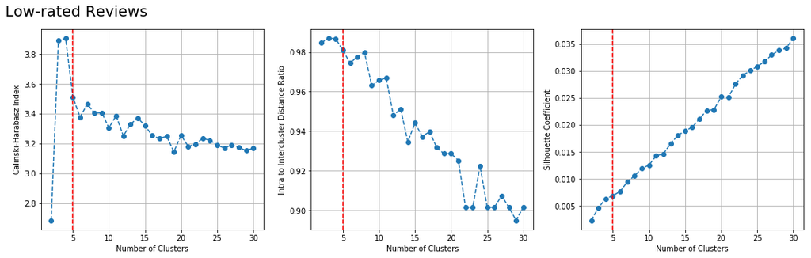

```python
k_test('Low', bow['Low'], k_max=30, k_spec=5)
```